# ANALYZING AND PREDICTING USED CAR PRICES IN INDIA

# By: Khushal Sai

```python
import numpy as np
import pandas as pd
import matplotlib.pyplot as plt
import seaborn as sns
from sklearn.linear_model import LinearRegression
```

```python
df = pd.read_excel('Sample+data_used_cars_India1.xlsx')  # reading file
df.head()
```

|  | Unnamed: 0 | Name | Location | Year | Kilometers_Driven | Fuel_Type | Transmission | Owner_Type | Mileage | Engine | Power | Seats | New_Price | Price | Unnamed: 14 | Unnamed: 15 | Unnamed: 16 | Unnamed: 17 |
| --- | --- | --- | --- | --- | --- | --- | --- | --- | --- | --- | --- | --- | --- | --- | --- | --- | --- | --- |
| 0 | 1221 | Ambassador Classic Nova Diesel | Chennai | 2003 | 80000 | Diesel | Manual | Third | 12.8 kmpl | 1489 CC | 35.5 bhp | 5.0 | NaN | 1.35 | NaN | NaN | NaN | NaN |
| 1 | 398 | Audi A3 35 TDI Attraction | Chennai | 2014 | 79271 | Diesel | Automatic | First | 20.38 kmpl | 1968 CC | 143 bhp | 5.0 | NaN | 16.50 | NaN | NaN | NaN | Ambassador Classic Nova Diesel |
| 2 | 4782 | Audi A3 35 TDI Premium | Mumbai | 2016 | 20003 | Diesel | Automatic | First | 20.38 kmpl | 1968 CC | 143 bhp | 5.0 | NaN | 19.25 | NaN | 781.00 | 2626.0 | Audi A3 35 TDI Attraction |
| 3 | 4989 | Audi A3 35 TDI Premium Plus | Mumbai | 2016 | 39000 | Diesel | Automatic | First | 20.38 kmpl | 1968 CC | 143 bhp | 5.0 | 42.89 Lakh | 18.90 | NaN | 4.08 | NaN | Audi A3 35 TDI Premium |
| 4 | 1954 | Audi A3 35 TDI Technology | Delhi | 2017 | 22000 | Diesel | Automatic | Second | 20.38 kmpl | 1968 CC | 143 bhp | 5.0 | NaN | 22.50 | NaN | NaN | NaN | Audi A3 35 TDI Premium Plus |

```python
df.shape
```

```
(6019, 18)
```

```python
df.info() # info
```

```
<class 'pandas.core.frame.DataFrame'>
RangeIndex: 6019 entries, 0 to 6018
Data columns (total 18 columns):
 #   Column             Non-Null Count  Dtype
---  ------             --------------  -----
 0   Unnamed: 0         6019 non-null   int64
 1   Name               6019 non-null   object
 2   Location           6019 non-null   object
 3   Year               6019 non-null   int64
 4   Kilometers_Driven  6019 non-null   int64
 5   Fuel_Type          6019 non-null   object
 6   Transmission       6019 non-null   object
 7   Owner_Type         6019 non-null   object
 8   Mileage            6017 non-null   object
 9   Engine             5983 non-null   object
 10  Power              5983 non-null   object
 11  Seats              5977 non-null   float64
 12  New_Price          824 non-null    object
 13  Price              6019 non-null   float64
 14  Unnamed: 14        0 non-null      float64
 15  Unnamed: 15        2 non-null      float64
 16  Unnamed: 16        1 non-null      float64
 17  Unnamed: 17        1852 non-null   object
dtypes: float64(5), int64(3), object(10)
memory usage: 846.5+ KB
```

## Renaming Req Column name

```python
df.rename(columns = {'Unnamed: 0':'S.No'}, inplace = True)    # renaming the require column names
df.drop(columns=['Unnamed: 14','Unnamed: 15','Unnamed: 16','Unnamed: 17'],axis=1,inplace=True) # dropping columns
```

```python
df.head()
```

|  | S.No | Name | Location | Year | Kilometers_Driven | Fuel_Type | Transmission | Owner_Type | Mileage | Engine | Power | Seats | New_Price | Price |
| --- | --- | --- | --- | --- | --- | --- | --- | --- | --- | --- | --- | --- | --- | --- |
| 0 | 1221 | Ambassador Classic Nova Diesel | Chennai | 2003 | 80000 | Diesel | Manual | Third | 12.8 kmpl | 1489 CC | 35.5 bhp | 5.0 | NaN | 1.35 |
| 1 | 398 | Audi A3 35 TDI Attraction | Chennai | 2014 | 79271 | Diesel | Automatic | First | 20.38 kmpl | 1968 CC | 143 bhp | 5.0 | NaN | 16.50 |
| 2 | 4782 | Audi A3 35 TDI Premium | Mumbai | 2016 | 20003 | Diesel | Automatic | First | 20.38 kmpl | 1968 CC | 143 bhp | 5.0 | NaN | 19.25 |
| 3 | 4989 | Audi A3 35 TDI Premium Plus | Mumbai | 2016 | 39000 | Diesel | Automatic | First | 20.38 kmpl | 1968 CC | 143 bhp | 5.0 | 42.89 Lakh | 18.90 |
| 4 | 1954 | Audi A3 35 TDI Technology | Delhi | 2017 | 22000 | Diesel | Automatic | Second | 20.38 kmpl | 1968 CC | 143 bhp | 5.0 | NaN | 22.50 |

```python
df.shape # shape
```

```
(6019, 14)
```

## Drop 'New Price' column which is not required

```python
df.drop(['New_Price'],axis=1,inplace=True) # droping New price column which is not required
```

```python
df.head() # top records
```

|  | S.No | Name | Location | Year | Kilometers_Driven | Fuel_Type | Transmission | Owner_Type | Mileage | Engine | Power | Seats | Price |
| --- | --- | --- | --- | --- | --- | --- | --- | --- | --- | --- | --- | --- | --- |
| 0 | 1221 | Ambassador Classic Nova Diesel | Chennai | 2003 | 80000 | Diesel | Manual | Third | 12.8 kmpl | 1489 CC | 35.5 bhp | 5.0 | 1.35 |
| 1 | 398 | Audi A3 35 TDI Attraction | Chennai | 2014 | 79271 | Diesel | Automatic | First | 20.38 kmpl | 1968 CC | 143 bhp | 5.0 | 16.50 |
| 2 | 4782 | Audi A3 35 TDI Premium | Mumbai | 2016 | 20003 | Diesel | Automatic | First | 20.38 kmpl | 1968 CC | 143 bhp | 5.0 | 19.25 |
| 3 | 4989 | Audi A3 35 TDI Premium Plus | Mumbai | 2016 | 39000 | Diesel | Automatic | First | 20.38 kmpl | 1968 CC | 143 bhp | 5.0 | 18.90 |
| 4 | 1954 | Audi A3 35 TDI Technology | Delhi | 2017 | 22000 | Diesel | Automatic | Second | 20.38 kmpl | 1968 CC | 143 bhp | 5.0 | 22.50 |

## Now I have to extract the company name from the column 'Name'

## Assign this to a new variable 'new_col_values'

```python
# Extracting Company name by using split and storing into in a new variable
new_col_values = df['Name'].str.split(' ').str[0]
```

## Inserting a new column 'Company_name' at particular column number

```python
# I am using insert function to add new column at particular column number
df.insert(loc = 2,
          column = 'Company_name',
          value = new_col_values)    # inserting the col new_col_values at required index in the dataframe
```

```python
df.head()
```

|  | S.No | Name | Company_name | Location | Year | Kilometers_Driven | Fuel_Type | Transmission | Owner_Type | Mileage | Engine | Power | Seats | Price |
| --- | --- | --- | --- | --- | --- | --- | --- | --- | --- | --- | --- | --- | --- | --- |
| 0 | 1221 | Ambassador Classic Nova Diesel | Ambassador | Chennai | 2003 | 80000 | Diesel | Manual | Third | 12.8 kmpl | 1489 CC | 35.5 bhp | 5.0 | 1.35 |
| 1 | 398 | Audi A3 35 TDI Attraction | Audi | Chennai | 2014 | 79271 | Diesel | Automatic | First | 20.38 kmpl | 1968 CC | 143 bhp | 5.0 | 16.50 |
| 2 | 4782 | Audi A3 35 TDI Premium | Audi | Mumbai | 2016 | 20003 | Diesel | Automatic | First | 20.38 kmpl | 1968 CC | 143 bhp | 5.0 | 19.25 |
| 3 | 4989 | Audi A3 35 TDI Premium Plus | Audi | Mumbai | 2016 | 39000 | Diesel | Automatic | First | 20.38 kmpl | 1968 CC | 143 bhp | 5.0 | 18.90 |
| 4 | 1954 | Audi A3 35 TDI Technology | Audi | Delhi | 2017 | 22000 | Diesel | Automatic | Second | 20.38 kmpl | 1968 CC | 143 bhp | 5.0 | 22.50 |

```python
df.dtypes
```

```
S.No                   int64
Name                  object
Company_name          object
Location              object
Year                   int64
Kilometers_Driven      int64
Fuel_Type             object
Transmission          object
Owner_Type            object
Mileage               object
Engine                object
Power                 object
Seats                float64
Price                float64
dtype: object
```

```python
df['Company_name'].unique() # checking unique values in Company_name
```

```
array(['Ambassador', 'Audi', 'Bentley', 'BMW', 'Chevrolet', 'Datsun',
       'Fiat', 'Force', 'Ford', 'Honda', 'Hyundai', 'ISUZU', 'Isuzu',
       'Jaguar', 'Jeep', 'Lamborghini', 'Land', 'Mahindra', 'Maruti',
       'Mercedes-Benz', 'Mini', 'Mitsubishi', 'Nissan', 'Porsche',
       'Renault', 'Skoda', 'Smart', 'Tata', 'Toyota', 'Volkswagen',
       'Volvo'], dtype=object)
```

```python
df.Location.unique() # checking unique values in Location
```

```
array(['Chennai', 'Mumbai', 'Delhi', 'Kolkata', 'Hyderabad', 'Kochi',
       'Ahmedabad', 'Bangalore', 'Coimbatore', 'Pune', 'Jaipur'],
      dtype=object)
```

# ------Encoding columns 'Company_name' and 'Location'------

## As the columns are noimnal and are not ordered so we can use 'Mean encoding'

## To get the mean values for respective columns we use pivot table function

## 1. Making Pivot table for 'Company_name' and 'Price'

```python
# Creating Pivot table for Company_name and Price
piv_tab_comp_Price = df.pivot_table(index='Company_name', values='Price',aggfunc='mean')
```

```python
piv_tab_comp_Price
```

| Company_name | Price |
| --- | --- |
| Ambassador | 1.350000 |
| Audi | 25.537712 |
| BMW | 25.243146 |
| Bentley | 59.000000 |
| Chevrolet | 3.044463 |
| Datsun | 3.049231 |
| Fiat | 3.269286 |
| Force | 9.333333 |
| Ford | 6.889400 |
| Honda | 5.411743 |
| Hyundai | 5.343433 |
| ISUZU | 12.045000 |
| Isuzu | 20.000000 |
| Jaguar | 37.632250 |
| Jeep | 18.718667 |
| Lamborghini | 120.000000 |
| Land | 39.259500 |
| Mahindra | 8.045919 |
| Maruti | 4.517267 |
| Mercedes-Benz | 26.809874 |
| Mini | 26.896923 |
| Mitsubishi | 11.058889 |
| Nissan | 4.738352 |
| Porsche | 48.348333 |
| Renault | 5.799034 |
| Skoda | 7.559075 |
| Smart | 3.000000 |
| Tata | 3.562849 |
| Toyota | 11.580024 |
| Volkswagen | 5.307270 |
| Volvo | 18.802857 |

## Converting pivot table to Data frame by using 'reset_index' function

```python
# Converting pivot table to Data frame using reset_index # Creating Pivot table for Company_name and Price
piv_tab_comp_Price = piv_tab_comp_Price.reset_index()
piv_tab_comp_Price
```

|  | Company_name | Price |
| --- | --- | --- |
| 0 | Ambassador | 1.350000 |
| 1 | Audi | 25.537712 |
| 2 | BMW | 25.243146 |
| 3 | Bentley | 59.000000 |
| 4 | Chevrolet | 3.044463 |
| 5 | Datsun | 3.049231 |
| 6 | Fiat | 3.269286 |
| 7 | Force | 9.333333 |
| 8 | Ford | 6.889400 |
| 9 | Honda | 5.411743 |
| 10 | Hyundai | 5.343433 |
| 11 | ISUZU | 12.045000 |
| 12 | Isuzu | 20.000000 |
| 13 | Jaguar | 37.632250 |
| 14 | Jeep | 18.718667 |
| 15 | Lamborghini | 120.000000 |
| 16 | Land | 39.259500 |
| 17 | Mahindra | 8.045919 |
| 18 | Maruti | 4.517267 |
| 19 | Mercedes-Benz | 26.809874 |
| 20 | Mini | 26.896923 |
| 21 | Mitsubishi | 11.058889 |
| 22 | Nissan | 4.738352 |
| 23 | Porsche | 48.348333 |
| 24 | Renault | 5.799034 |
| 25 | Skoda | 7.559075 |
| 26 | Smart | 3.000000 |
| 27 | Tata | 3.562849 |
| 28 | Toyota | 11.580024 |
| 29 | Volkswagen | 5.307270 |
| 30 | Volvo | 18.802857 |

## Merging 'df' dataframe and 'piv_tab_comp_Price' dataframe and storing this into new variable df1

```python
# Merging df dataframe and piv_tab_comp_Price dataframe and storing this into new variable
df1= pd.merge(df, piv_tab_comp_Price, on ='Company_name', how ='inner')
df1.head()
```

|  | S.No | Name | Company_name | Location | Year | Kilometers_Driven | Fuel_Type | Transmission | Owner_Type | Mileage | Engine | Power | Seats | Price_x | Price_y |
| --- | --- | --- | --- | --- | --- | --- | --- | --- | --- | --- | --- | --- | --- | --- | --- |
| 0 | 1221 | Ambassador Classic Nova Diesel | Ambassador | Chennai | 2003 | 80000 | Diesel | Manual | Third | 12.8 kmpl | 1489 CC | 35.5 bhp | 5.0 | 1.35 | 1.350000 |
| 1 | 398 | Audi A3 35 TDI Attraction | Audi | Chennai | 2014 | 79271 | Diesel | Automatic | First | 20.38 kmpl | 1968 CC | 143 bhp | 5.0 | 16.50 | 25.537712 |
| 2 | 4782 | Audi A3 35 TDI Premium | Audi | Mumbai | 2016 | 20003 | Diesel | Automatic | First | 20.38 kmpl | 1968 CC | 143 bhp | 5.0 | 19.25 | 25.537712 |
| 3 | 4989 | Audi A3 35 TDI Premium Plus | Audi | Mumbai | 2016 | 39000 | Diesel | Automatic | First | 20.38 kmpl | 1968 CC | 143 bhp | 5.0 | 18.90 | 25.537712 |
| 4 | 1954 | Audi A3 35 TDI Technology | Audi | Delhi | 2017 | 22000 | Diesel | Automatic | Second | 20.38 kmpl | 1968 CC | 143 bhp | 5.0 | 22.50 | 25.537712 |

```python
df1.shape
```

```
(6019, 15)
```

## In order to move the column, first we have to pop the column and store in a variable and using insert function define position, new col name and the newly created variable

```python
avg_price_for_comp = df1.pop('Price_y')
```

```python
df1.insert(3,'Company_num',avg_price_for_comp)
```

```python
df1.head()
```

|  | S.No | Name | Company_name | Company_num | Location | Year | Kilometers_Driven | Fuel_Type | Transmission | Owner_Type | Mileage | Engine | Power | Seats | Price_x |
| --- | --- | --- | --- | --- | --- | --- | --- | --- | --- | --- | --- | --- | --- | --- | --- |
| 0 | 1221 | Ambassador Classic Nova Diesel | Ambassador | 1.350000 | Chennai | 2003 | 80000 | Diesel | Manual | Third | 12.8 kmpl | 1489 CC | 35.5 bhp | 5.0 | 1.35 |
| 1 | 398 | Audi A3 35 TDI Attraction | Audi | 25.537712 | Chennai | 2014 | 79271 | Diesel | Automatic | First | 20.38 kmpl | 1968 CC | 143 bhp | 5.0 | 16.50 |
| 2 | 4782 | Audi A3 35 TDI Premium | Audi | 25.537712 | Mumbai | 2016 | 20003 | Diesel | Automatic | First | 20.38 kmpl | 1968 CC | 143 bhp | 5.0 | 19.25 |
| 3 | 4989 | Audi A3 35 TDI Premium Plus | Audi | 25.537712 | Mumbai | 2016 | 39000 | Diesel | Automatic | First | 20.38 kmpl | 1968 CC | 143 bhp | 5.0 | 18.90 |
| 4 | 1954 | Audi A3 35 TDI Technology | Audi | 25.537712 | Delhi | 2017 | 22000 | Diesel | Automatic | Second | 20.38 kmpl | 1968 CC | 143 bhp | 5.0 | 22.50 |

## Renaming column 'Price_x' to 'Price'

```python
df1.rename(columns={'Price_x':'Price'},inplace=True)
df1.head()
```

|  | S.No | Name | Company_name | Company_num | Location | Year | Kilometers_Driven | Fuel_Type | Transmission | Owner_Type | Mileage | Engine | Power | Seats | Price |
| --- | --- | --- | --- | --- | --- | --- | --- | --- | --- | --- | --- | --- | --- | --- | --- |
| 0 | 1221 | Ambassador Classic Nova Diesel | Ambassador | 1.350000 | Chennai | 2003 | 80000 | Diesel | Manual | Third | 12.8 kmpl | 1489 CC | 35.5 bhp | 5.0 | 1.35 |
| 1 | 398 | Audi A3 35 TDI Attraction | Audi | 25.537712 | Chennai | 2014 | 79271 | Diesel | Automatic | First | 20.38 kmpl | 1968 CC | 143 bhp | 5.0 | 16.50 |
| 2 | 4782 | Audi A3 35 TDI Premium | Audi | 25.537712 | Mumbai | 2016 | 20003 | Diesel | Automatic | First | 20.38 kmpl | 1968 CC | 143 bhp | 5.0 | 19.25 |
| 3 | 4989 | Audi A3 35 TDI Premium Plus | Audi | 25.537712 | Mumbai | 2016 | 39000 | Diesel | Automatic | First | 20.38 kmpl | 1968 CC | 143 bhp | 5.0 | 18.90 |
| 4 | 1954 | Audi A3 35 TDI Technology | Audi | 25.537712 | Delhi | 2017 | 22000 | Diesel | Automatic | Second | 20.38 kmpl | 1968 CC | 143 bhp | 5.0 | 22.50 |

```python
df1.Transmission.unique()
```

```
array(['Manual', 'Automatic'], dtype=object)
```

## 2. Making Pivot table for 'Location' and 'Price'

```python
# Creating Pivot table for Company_name and Price
piv_tab_loca_price = df.pivot_table(index='Location',values='Price')
```

```python
piv_tab_loca_price
```

| Location | Price |
| --- | --- |
| Ahmedabad | 8.457321 |
| Bangalore | 13.328631 |
| Chennai | 7.753623 |
| Coimbatore | 15.078223 |
| Delhi | 9.707726 |
| Hyderabad | 9.776550 |
| Jaipur | 5.809225 |
| Kochi | 11.179186 |
| Kolkata | 5.661215 |
| Mumbai | 9.429329 |
| Pune | 6.726254 |

```python
# Converting pivot table to Data frame using reset_index
piv_tab_loca_price = piv_tab_loca_price.reset_index()
piv_tab_loca_price
```

|  | Location | Price |
| --- | --- | --- |
| 0 | Ahmedabad | 8.457321 |
| 1 | Bangalore | 13.328631 |
| 2 | Chennai | 7.753623 |
| 3 | Coimbatore | 15.078223 |
| 4 | Delhi | 9.707726 |
| 5 | Hyderabad | 9.776550 |
| 6 | Jaipur | 5.809225 |
| 7 | Kochi | 11.179186 |
| 8 | Kolkata | 5.661215 |
| 9 | Mumbai | 9.429329 |
| 10 | Pune | 6.726254 |

## Merging 'df1' dataframe and 'piv_tab_loca_Price' dataframe and storing this into new variable df2

```python
df2 = pd.merge(df1, piv_tab_loca_price, on ='Location', how ='inner')
df2
```

|  | S.No | Name | Company_name | Company_num | Location | Year | Kilometers_Driven | Fuel_Type | Transmission | Owner_Type | Mileage | Engine | Power | Seats | Price_x | Price_y |
| --- | --- | --- | --- | --- | --- | --- | --- | --- | --- | --- | --- | --- | --- | --- | --- | --- |
| 0 | 1221 | Ambassador Classic Nova Diesel | Ambassador | 1.350000 | Chennai | 2003 | 80000 | Diesel | Manual | Third | 12.8 kmpl | 1489 CC | 35.5 bhp | 5.0 | 1.35 | 7.753623 |
| 1 | 398 | Audi A3 35 TDI Attraction | Audi | 25.537712 | Chennai | 2014 | 79271 | Diesel | Automatic | First | 20.38 kmpl | 1968 CC | 143 bhp | 5.0 | 16.50 | 7.753623 |
| 2 | 1929 | Audi A4 2.0 TDI 177 Bhp Premium Plus | Audi | 25.537712 | Chennai | 2014 | 70000 | Diesel | Automatic | First | 17.11 kmpl | 1968 CC | 174.33 bhp | 5.0 | 18.00 | 7.753623 |
| 3 | 5776 | Audi A4 2.0 TDI 177 Bhp Premium Plus | Audi | 25.537712 | Chennai | 2014 | 40000 | Diesel | Automatic | First | 17.11 kmpl | 1968 CC | 174.33 bhp | 5.0 | 22.00 | 7.753623 |
| 4 | 2484 | Audi A4 35 TDI Premium Sport | Audi | 25.537712 | Chennai | 2016 | 11000 | Diesel | Automatic | First | 17.11 kmpl | 1968 CC | 174.33 bhp | 5.0 | 28.00 | 7.753623 |
| ... | ... | ... | ... | ... | ... | ... | ... | ... | ... | ... | ... | ... | ... | ... | ... | ... |
| 6014 | 4550 | Volkswagen Vento 1.5 TDI Highline | Volkswagen | 5.307270 | Jaipur | 2015 | 58000 | Diesel | Manual | First | 20.34 kmpl | 1498 CC | 103.2 bhp | 5.0 | 5.85 | 5.809225 |
| 6015 | 4208 | Volkswagen Vento 1.6 Highline | Volkswagen | 5.307270 | Jaipur | 2016 | 33000 | Petrol | Manual | First | 16.09 kmpl | 1598 CC | 103.5 bhp | 5.0 | 7.70 | 5.809225 |
| 6016 | 844 | Volkswagen Vento Diesel Comfortline | Volkswagen | 5.307270 | Jaipur | 2013 | 125000 | Diesel | Manual | Second | 20.54 kmpl | 1598 CC | 103.6 bhp | 5.0 | 6.25 | 5.809225 |
| 6017 | 1536 | Volkswagen Vento Diesel Highline | Volkswagen | 5.307270 | Jaipur | 2011 | 50000 | Diesel | Manual | First | 20.54 kmpl | 1598 CC | 103.6 bhp | 5.0 | 5.00 | 5.809225 |
| 6018 | 2919 | Volkswagen Vento Diesel Highline | Volkswagen | 5.307270 | Jaipur | 2013 | 144000 | Diesel | Manual | First | 20.54 kmpl | 1598 CC | 103.6 bhp | 5.0 | 7.00 | 5.809225 |

6019 rows × 16 columns

## In order to move the column, first we have to pop the column and store in a variable and using insert function define position, new col name and the newly created variable

```python
avg_price_for_loca = df2.pop('Price_y')
```

```python
avg_price_for_loca
```

```
0       7.753623
1       7.753623
2       7.753623
3       7.753623
4       7.753623
          ...
6014    5.809225
6015    5.809225
6016    5.809225
6017    5.809225
6018    5.809225
Name: Price_y, Length: 6019, dtype: float64
```

```python
df2.insert(5,'Location_num',avg_price_for_loca)
df2
```

|  | S.No | Name | Company_name | Company_num | Location | Location_num | Year | Kilometers_Driven | Fuel_Type | Transmission | Owner_Type | Mileage | Engine | Power | Seats | Price_x |
| --- | --- | --- | --- | --- | --- | --- | --- | --- | --- | --- | --- | --- | --- | --- | --- | --- |
| 0 | 1221 | Ambassador Classic Nova Diesel | Ambassador | 1.350000 | Chennai | 7.753623 | 2003 | 80000 | Diesel | Manual | Third | 12.8 kmpl | 1489 CC | 35.5 bhp | 5.0 | 1.35 |
| 1 | 398 | Audi A3 35 TDI Attraction | Audi | 25.537712 | Chennai | 7.753623 | 2014 | 79271 | Diesel | Automatic | First | 20.38 kmpl | 1968 CC | 143 bhp | 5.0 | 16.50 |
| 2 | 1929 | Audi A4 2.0 TDI 177 Bhp Premium Plus | Audi | 25.537712 | Chennai | 7.753623 | 2014 | 70000 | Diesel | Automatic | First | 17.11 kmpl | 1968 CC | 174.33 bhp | 5.0 | 18.00 |
| 3 | 5776 | Audi A4 2.0 TDI 177 Bhp Premium Plus | Audi | 25.537712 | Chennai | 7.753623 | 2014 | 40000 | Diesel | Automatic | First | 17.11 kmpl | 1968 CC | 174.33 bhp | 5.0 | 22.00 |
| 4 | 2484 | Audi A4 35 TDI Premium Sport | Audi | 25.537712 | Chennai | 7.753623 | 2016 | 11000 | Diesel | Automatic | First | 17.11 kmpl | 1968 CC | 174.33 bhp | 5.0 | 28.00 |
| ... | ... | ... | ... | ... | ... | ... | ... | ... | ... | ... | ... | ... | ... | ... | ... | ... |
| 6014 | 4550 | Volkswagen Vento 1.5 TDI Highline | Volkswagen | 5.307270 | Jaipur | 5.809225 | 2015 | 58000 | Diesel | Manual | First | 20.34 kmpl | 1498 CC | 103.2 bhp | 5.0 | 5.85 |
| 6015 | 4208 | Volkswagen Vento 1.6 Highline | Volkswagen | 5.307270 | Jaipur | 5.809225 | 2016 | 33000 | Petrol | Manual | First | 16.09 kmpl | 1598 CC | 103.5 bhp | 5.0 | 7.70 |
| 6016 | 844 | Volkswagen Vento Diesel Comfortline | Volkswagen | 5.307270 | Jaipur | 5.809225 | 2013 | 125000 | Diesel | Manual | Second | 20.54 kmpl | 1598 CC | 103.6 bhp | 5.0 | 6.25 |
| 6017 | 1536 | Volkswagen Vento Diesel Highline | Volkswagen | 5.307270 | Jaipur | 5.809225 | 2011 | 50000 | Diesel | Manual | First | 20.54 kmpl | 1598 CC | 103.6 bhp | 5.0 | 5.00 |
| 6018 | 2919 | Volkswagen Vento Diesel Highline | Volkswagen | 5.307270 | Jaipur | 5.809225 | 2013 | 144000 | Diesel | Manual | First | 20.54 kmpl | 1598 CC | 103.6 bhp | 5.0 | 7.00 |

6019 rows × 16 columns

## Renaming column 'Price_x' to 'Price'

```python
df2.rename(columns={'Price_x':'Price'},inplace=True)
df2.head()
```

|  | S.No | Name | Company_name | Company_num | Location | Location_num | Year | Kilometers_Driven | Fuel_Type | Transmission | Owner_Type | Mileage | Engine | Power | Seats | Price |
| --- | --- | --- | --- | --- | --- | --- | --- | --- | --- | --- | --- | --- | --- | --- | --- | --- |
| 0 | 1221 | Ambassador Classic Nova Diesel | Ambassador | 1.350000 | Chennai | 7.753623 | 2003 | 80000 | Diesel | Manual | Third | 12.8 kmpl | 1489 CC | 35.5 bhp | 5.0 | 1.35 |
| 1 | 398 | Audi A3 35 TDI Attraction | Audi | 25.537712 | Chennai | 7.753623 | 2014 | 79271 | Diesel | Automatic | First | 20.38 kmpl | 1968 CC | 143 bhp | 5.0 | 16.50 |
| 2 | 1929 | Audi A4 2.0 TDI 177 Bhp Premium Plus | Audi | 25.537712 | Chennai | 7.753623 | 2014 | 70000 | Diesel | Automatic | First | 17.11 kmpl | 1968 CC | 174.33 bhp | 5.0 | 18.00 |
| 3 | 5776 | Audi A4 2.0 TDI 177 Bhp Premium Plus | Audi | 25.537712 | Chennai | 7.753623 | 2014 | 40000 | Diesel | Automatic | First | 17.11 kmpl | 1968 CC | 174.33 bhp | 5.0 | 22.00 |
| 4 | 2484 | Audi A4 35 TDI Premium Sport | Audi | 25.537712 | Chennai | 7.753623 | 2016 | 11000 | Diesel | Automatic | First | 17.11 kmpl | 1968 CC | 174.33 bhp | 5.0 | 28.00 |

## Checking null values for other columns

```python
df2['Mileage'].isnull().sum()
```

```
2
```

```python
df2['Engine'].dtype
```

```
dtype('O')
```

```python
df2['Engine'].unique()
```

```
array(['1489 CC', '1968 CC', '2967 CC', '1995 CC', '2993 CC', '936 CC',
       '1199 CC', '1991 CC', '1248 CC', '995 CC', '799 CC', '1172 CC',
       '2200 CC', '1399 CC', '1498 CC', '1499 CC', '2198 CC', '2953 CC',
       '3198 CC', '2499 CC', '1388 CC', '1596 CC', '1196 CC', '1299 CC',
       '2354 CC', '2997 CC', '1198 CC', '1497 CC', '1799 CC', '1997 CC',
       '1495 CC', '1582 CC', '1591 CC', '1197 CC', '814 CC', '1186 CC',
       '1120 CC', '1086 CC', '1396 CC', '2199 CC', '999 CC', '1493 CC',
       '1599 CC', '2179 CC', '2523 CC', '72 CC', '2112 CC', '1461 CC',
       '2609 CC', '2489 CC', '796 CC', '998 CC', '1061 CC', '1373 CC',
       '1298 CC', nan, '1598 CC', '1586 CC', '993 CC', '2143 CC',
       '2987 CC', '2148 CC', '1796 CC', '1998 CC', '1999 CC', '1468 CC',
       '3200 CC', '2835 CC', '1896 CC', '1193 CC', '1405 CC', '624 CC',
       '2494 CC', '2362 CC', '1798 CC', '1794 CC', '1364 CC', '1496 CC',
       '2982 CC', '2393 CC', '2755 CC', '1985 CC', '2400 CC', '1781 CC',
       '1984 CC', '2698 CC', '2894 CC', '2497 CC', '4395 CC', '1150 CC',
       '1368 CC', '1194 CC', '1797 CC', '1341 CC', '2359 CC', '1956 CC',
       '1390 CC', '2696 CC', '2498 CC', '1462 CC', '1595 CC', '1950 CC',
       '3498 CC', '2496 CC', '2477 CC', '2349 CC', '4806 CC', '3436 CC',
       '1422 CC', '1395 CC', '1978 CC', '2446 CC', '4134 CC', '2979 CC',
       '2495 CC', '1343 CC', '5204 CC', '2360 CC', '2996 CC', '2149 CC',
       '793 CC', '5461 CC', '2706 CC', '2771 CC', '1948 CC', '3197 CC',
       '5998 CC', '5000 CC', '970 CC', '1590 CC', '3597 CC', '2956 CC',
       '1047 CC', '1969 CC', '4951 CC', '2995 CC', '2773 CC', '4367 CC',
       '2147 CC', '2925 CC', '2694 CC', '2487 CC', '1242 CC', '1597 CC',
       '2720 CC', '2999 CC', '2092 CC'], dtype=object)
```

## As the column 'Engine' is 'object' type we have to make the column to suitable format and convert that into 'int' type

## Alternate method : Using split function: df2['Engine'] = df2['Engine'].str.split('CC').str[0] and replace with space

```python
# Using regex function for converting it into suitable values
df2 = df2.replace({
    'Engine':'[A-Za-z]'},'',
    regex=True)
```

```python
df2.head()
```

|  | S.No | Name | Company_name | Company_num | Location | Location_num | Year | Kilometers_Driven | Fuel_Type | Transmission | Owner_Type | Mileage | Engine | Power | Seats | Price |
| --- | --- | --- | --- | --- | --- | --- | --- | --- | --- | --- | --- | --- | --- | --- | --- | --- |
| 0 | 1221 | Ambassador Classic Nova Diesel | Ambassador | 1.350000 | Chennai | 7.753623 | 2003 | 80000 | Diesel | Manual | Third | 12.8 kmpl | 1489 | 35.5 bhp | 5.0 | 1.35 |
| 1 | 398 | Audi A3 35 TDI Attraction | Audi | 25.537712 | Chennai | 7.753623 | 2014 | 79271 | Diesel | Automatic | First | 20.38 kmpl | 1968 | 143 bhp | 5.0 | 16.50 |
| 2 | 1929 | Audi A4 2.0 TDI 177 Bhp Premium Plus | Audi | 25.537712 | Chennai | 7.753623 | 2014 | 70000 | Diesel | Automatic | First | 17.11 kmpl | 1968 | 174.33 bhp | 5.0 | 18.00 |
| 3 | 5776 | Audi A4 2.0 TDI 177 Bhp Premium Plus | Audi | 25.537712 | Chennai | 7.753623 | 2014 | 40000 | Diesel | Automatic | First | 17.11 kmpl | 1968 | 174.33 bhp | 5.0 | 22.00 |
| 4 | 2484 | Audi A4 35 TDI Premium Sport | Audi | 25.537712 | Chennai | 7.753623 | 2016 | 11000 | Diesel | Automatic | First | 17.11 kmpl | 1968 | 174.33 bhp | 5.0 | 28.00 |

```python
df2['Engine'].unique()
```

```
array(['1489 ', '1968 ', '2967 ', '1995 ', '2993 ', '936 ', '1199 ',
       '1991 ', '1248 ', '995 ', '799 ', '1172 ', '2200 ', '1399 ',
       '1498 ', '1499 ', '2198 ', '2953 ', '3198 ', '2499 ', '1388 ',
       '1596 ', '1196 ', '1299 ', '2354 ', '2997 ', '1198 ', '1497 ',
       '1799 ', '1997 ', '1495 ', '1582 ', '1591 ', '1197 ', '814 ',
       '1186 ', '1120 ', '1086 ', '1396 ', '2199 ', '999 ', '1493 ',
       '1599 ', '2179 ', '2523 ', '72 ', '2112 ', '1461 ', '2609 ',
       '2489 ', '796 ', '998 ', '1061 ', '1373 ', '1298 ', nan, '1598 ',
       '1586 ', '993 ', '2143 ', '2987 ', '2148 ', '1796 ', '1998 ',
       '1999 ', '1468 ', '3200 ', '2835 ', '1896 ', '1193 ', '1405 ',
       '624 ', '2494 ', '2362 ', '1798 ', '1794 ', '1364 ', '1496 ',
       '2982 ', '2393 ', '2755 ', '1985 ', '2400 ', '1781 ', '1984 ',
       '2698 ', '2894 ', '2497 ', '4395 ', '1150 ', '1368 ', '1194 ',
       '1797 ', '1341 ', '2359 ', '1956 ', '1390 ', '2696 ', '2498 ',
       '1462 ', '1595 ', '1950 ', '3498 ', '2496 ', '2477 ', '2349 ',
       '4806 ', '3436 ', '1422 ', '1395 ', '1978 ', '2446 ', '4134 ',
       '2979 ', '2495 ', '1343 ', '5204 ', '2360 ', '2996 ', '2149 ',
       '793 ', '5461 ', '2706 ', '2771 ', '1948 ', '3197 ', '5998 ',
       '5000 ', '970 ', '1590 ', '3597 ', '2956 ', '1047 ', '1969 ',
       '4951 ', '2995 ', '2773 ', '4367 ', '2147 ', '2925 ', '2694 ',
       '2487 ', '1242 ', '1597 ', '2720 ', '2999 ', '2092 '], dtype=object)
```

```python
df2['Engine'].dtype
```

```
dtype('O')
```

```python
df2[df2['Engine'].isnull()]
```

|  | S.No | Name | Company_name | Company_num | Location | Location_num | Year | Kilometers_Driven | Fuel_Type | Transmission | Owner_Type | Mileage | Engine | Power | Seats | Price |
| --- | --- | --- | --- | --- | --- | --- | --- | --- | --- | --- | --- | --- | --- | --- | --- | --- |
| 290 | 733 | Maruti Swift 1.3 VXi | Maruti | 4.517267 | Chennai | 7.753623 | 2006 | 97800 | Petrol | Manual | Third | 16.1 kmpl | NaN | NaN | NaN | 1.75 |
| 547 | 3272 | BMW 5 Series 520d Sedan | BMW | 25.243146 | Mumbai | 9.429329 | 2008 | 81000 | Diesel | Automatic | Second | 18.48 kmpl | NaN | NaN | NaN | 10.50 |
| 853 | 749 | Land Rover Range Rover 3.0 D | Land | 39.259500 | Mumbai | 9.429329 | 2008 | 55001 | Diesel | Automatic | Second | 0.0 kmpl | NaN | NaN | NaN | 26.50 |
| 854 | 4152 | Land Rover Range Rover 3.0 D | Land | 39.259500 | Mumbai | 9.429329 | 2003 | 75000 | Diesel | Automatic | Second | 0.0 kmpl | NaN | NaN | NaN | 16.11 |
| 956 | 2335 | Maruti Swift 1.3 VXi | Maruti | 4.517267 | Mumbai | 9.429329 | 2007 | 55000 | Petrol | Manual | Second | 16.1 kmpl | NaN | NaN | NaN | 1.75 |
| 1320 | 3520 | BMW 5 Series 520d Sedan | BMW | 25.243146 | Delhi | 9.707726 | 2012 | 90000 | Diesel | Automatic | First | 18.48 kmpl | NaN | NaN | NaN | 14.50 |
| 1321 | 4577 | BMW 5 Series 520d Sedan | BMW | 25.243146 | Delhi | 9.707726 | 2012 | 72000 | Diesel | Automatic | Third | 18.48 kmpl | NaN | NaN | NaN | 13.85 |
| 1369 | 1294 | Honda City 1.3 DX | Honda | 5.411743 | Delhi | 9.707726 | 2009 | 55005 | Petrol | Manual | First | 12.8 kmpl | NaN | NaN | NaN | 3.20 |
| 1605 | 5185 | Maruti Swift 1.3 LXI | Maruti | 4.517267 | Delhi | 9.707726 | 2012 | 52000 | Petrol | Manual | First | 16.1 kmpl | NaN | NaN | NaN | 3.65 |
| 1606 | 5015 | Maruti Swift 1.3 VXi | Maruti | 4.517267 | Delhi | 9.707726 | 2006 | 63000 | Petrol | Manual | First | 16.1 kmpl | NaN | NaN | NaN | 1.60 |
| 1892 | 4952 | Fiat Punto 1.4 Emotion | Fiat | 3.269286 | Kolkata | 5.661215 | 2010 | 47000 | Petrol | Manual | First | 14.6 kmpl | NaN | NaN | NaN | 1.49 |
| 1979 | 3810 | Honda CR-V AT With Sun Roof | Honda | 5.411743 | Kolkata | 5.661215 | 2013 | 27000 | Petrol | Automatic | First | 14.0 kmpl | NaN | NaN | NaN | 11.99 |
| 2180 | 208 | Maruti Swift 1.3 VXi | Maruti | 4.517267 | Kolkata | 5.661215 | 2010 | 42001 | Petrol | Manual | First | 16.1 kmpl | NaN | NaN | NaN | 2.11 |
| 2181 | 2668 | Maruti Swift 1.3 VXi | Maruti | 4.517267 | Kolkata | 5.661215 | 2014 | 32986 | Petrol | Manual | First | 16.1 kmpl | NaN | NaN | NaN | 4.24 |
| 2816 | 1327 | Maruti Swift 1.3 ZXI | Maruti | 4.517267 | Hyderabad | 9.776550 | 2015 | 50295 | Petrol | Manual | First | 16.1 kmpl | NaN | NaN | NaN | 5.80 |
| 3153 | 2530 | BMW 5 Series 520d Sedan | BMW | 25.243146 | Kochi | 11.179186 | 2014 | 64158 | Diesel | Automatic | First | 18.48 kmpl | NaN | NaN | NaN | 17.89 |
| 3185 | 4697 | Fiat Punto 1.2 Dynamic | Fiat | 3.269286 | Kochi | 11.179186 | 2017 | 17941 | Petrol | Manual | First | 15.7 kmpl | NaN | NaN | NaN | 3.93 |
| 3403 | 3522 | Hyundai Santro GLS II - Euro II | Hyundai | 5.343433 | Kochi | 11.179186 | 2012 | 66400 | Petrol | Manual | First | 0.0 kmpl | NaN | NaN | NaN | 2.66 |
| 3806 | 194 | Honda City 1.5 GXI | Honda | 5.411743 | Ahmedabad | 8.457321 | 2007 | 60006 | Petrol | Manual | First | 0.0 kmpl | NaN | NaN | NaN | 2.95 |
| 4080 | 5270 | Honda City 1.5 GXI | Honda | 5.411743 | Bangalore | 13.328631 | 2002 | 53000 | Petrol | Manual | Second | 0.0 kmpl | NaN | NaN | NaN | 1.85 |
| 4154 | 2542 | Hyundai Santro GLS II - Euro II | Hyundai | 5.343433 | Bangalore | 13.328631 | 2011 | 65000 | Petrol | Manual | Second | 0.0 kmpl | NaN | NaN | NaN | 3.15 |
| 4155 | 2842 | Hyundai Santro GLS II - Euro II | Hyundai | 5.343433 | Bangalore | 13.328631 | 2012 | 43000 | Petrol | Manual | First | 0.0 kmpl | NaN | NaN | NaN | 3.25 |
| 4158 | 4229 | Hyundai Santro Xing XG | Hyundai | 5.343433 | Bangalore | 13.328631 | 2005 | 79000 | Petrol | Manual | Second | 17.0 kmpl | NaN | NaN | NaN | 1.65 |
| 4640 | 2096 | Hyundai Santro LP zipPlus | Hyundai | 5.343433 | Coimbatore | 15.078223 | 2004 | 52146 | Petrol | Manual | First | 0.0 kmpl | NaN | NaN | NaN | 1.93 |
| 4676 | 1460 | Land Rover Range Rover Sport 2005 2012 Sport | Land | 39.259500 | Coimbatore | 15.078223 | 2008 | 69078 | Petrol | Manual | First | 0.0 kmpl | NaN | NaN | NaN | 40.88 |
| 5008 | 2623 | BMW 5 Series 520d Sedan | BMW | 25.243146 | Pune | 6.726254 | 2012 | 95000 | Diesel | Automatic | Second | 18.48 kmpl | NaN | NaN | NaN | 18.00 |
| 5043 | 4011 | Fiat Punto 1.3 Emotion | Fiat | 3.269286 | Pune | 6.726254 | 2011 | 45271 | Diesel | Manual | First | 20.3 kmpl | NaN | NaN | NaN | 2.60 |
| 5096 | 1385 | Honda City 1.5 GXI | Honda | 5.411743 | Pune | 6.726254 | 2004 | 115000 | Petrol | Manual | Second | 0.0 kmpl | NaN | NaN | NaN | 1.50 |
| 5130 | 4604 | Honda Jazz Select Edition | Honda | 5.411743 | Pune | 6.726254 | 2011 | 98000 | Petrol | Manual | First | 16.7 kmpl | NaN | NaN | NaN | 3.15 |
| 5201 | 2780 | Hyundai Santro GLS II - Euro II | Hyundai | 5.343433 | Pune | 6.726254 | 2009 | 100000 | Petrol | Manual | First | 0.0 kmpl | NaN | NaN | NaN | 1.60 |
| 5206 | 4712 | Hyundai Santro Xing XG | Hyundai | 5.343433 | Pune | 6.726254 | 2003 | 80000 | Petrol | Manual | Second | 17.0 kmpl | NaN | NaN | NaN | 0.90 |
| 5326 | 2074 | Maruti Swift 1.3 LXI | Maruti | 4.517267 | Pune | 6.726254 | 2011 | 24255 | Petrol | Manual | First | 16.1 kmpl | NaN | NaN | NaN | 3.15 |
| 5327 | 2325 | Maruti Swift 1.3 VXI ABS | Maruti | 4.517267 | Pune | 6.726254 | 2015 | 67000 | Petrol | Manual | First | 16.1 kmpl | NaN | NaN | NaN | 4.70 |
| 5539 | 2264 | Toyota Etios Liva V | Toyota | 11.580024 | Pune | 6.726254 | 2012 | 24500 | Petrol | Manual | Second | 18.3 kmpl | NaN | NaN | NaN | 2.95 |
| 5848 | 3404 | Maruti Swift 1.3 VXi | Maruti | 4.517267 | Jaipur | 5.809225 | 2006 | 125000 | Petrol | Manual | Fourth & Above | 16.1 kmpl | NaN | NaN | NaN | 2.35 |
| 5903 | 2737 | Maruti Wagon R Vx | Maruti | 4.517267 | Jaipur | 5.809225 | 2001 | 200000 | Petrol | Manual | First | 12.0 kmpl | NaN | NaN | NaN | 0.70 |

```python
len(df2[df2['Engine'].isnull()])
```

```
36
```

```python
df2['Engine'] = df2['Engine'].fillna(0)
```

```python
df2['Engine'].unique()
```

```
array(['1489 ', '1968 ', '2967 ', '1995 ', '2993 ', '936 ', '1199 ',
       '1991 ', '1248 ', '995 ', '799 ', '1172 ', '2200 ', '1399 ',
       '1498 ', '1499 ', '2198 ', '2953 ', '3198 ', '2499 ', '1388 ',
       '1596 ', '1196 ', '1299 ', '2354 ', '2997 ', '1198 ', '1497 ',
       '1799 ', '1997 ', '1495 ', '1582 ', '1591 ', '1197 ', '814 ',
       '1186 ', '1120 ', '1086 ', '1396 ', '2199 ', '999 ', '1493 ',
       '1599 ', '2179 ', '2523 ', '72 ', '2112 ', '1461 ', '2609 ',
       '2489 ', '796 ', '998 ', '1061 ', '1373 ', '1298 ', 0, '1598 ',
       '1586 ', '993 ', '2143 ', '2987 ', '2148 ', '1796 ', '1998 ',
       '1999 ', '1468 ', '3200 ', '2835 ', '1896 ', '1193 ', '1405 ',
       '624 ', '2494 ', '2362 ', '1798 ', '1794 ', '1364 ', '1496 ',
       '2982 ', '2393 ', '2755 ', '1985 ', '2400 ', '1781 ', '1984 ',
       '2698 ', '2894 ', '2497 ', '4395 ', '1150 ', '1368 ', '1194 ',
       '1797 ', '1341 ', '2359 ', '1956 ', '1390 ', '2696 ', '2498 ',
       '1462 ', '1595 ', '1950 ', '3498 ', '2496 ', '2477 ', '2349 ',
       '4806 ', '3436 ', '1422 ', '1395 ', '1978 ', '2446 ', '4134 ',
       '2979 ', '2495 ', '1343 ', '5204 ', '2360 ', '2996 ', '2149 ',
       '793 ', '5461 ', '2706 ', '2771 ', '1948 ', '3197 ', '5998 ',
       '5000 ', '970 ', '1590 ', '3597 ', '2956 ', '1047 ', '1969 ',
       '4951 ', '2995 ', '2773 ', '4367 ', '2147 ', '2925 ', '2694 ',
       '2487 ', '1242 ', '1597 ', '2720 ', '2999 ', '2092 '], dtype=object)
```

```python
df2[df2['Engine'].isnull()]
```

|  | S.No | Name | Company_name | Company_num | Location | Location_num | Year | Kilometers_Driven | Fuel_Type | Transmission | Owner_Type | Mileage | Engine | Power | Seats | Price |
| --- | --- | --- | --- | --- | --- | --- | --- | --- | --- | --- | --- | --- | --- | --- | --- | --- |

```python
df2['Engine'] = df2['Engine'].astype(int)
```

```python
df2['Engine']
```

```
0       1489
1       1968
2       1968
3       1968
4       1968
        ...
6014    1498
6015    1598
6016    1598
6017    1598
6018    1598
Name: Engine, Length: 6019, dtype: int32
```

```python
df2['Engine'].unique()
```

```
array([1489, 1968, 2967, 1995, 2993,  936, 1199, 1991, 1248,  995,  799,
       1172, 2200, 1399, 1498, 1499, 2198, 2953, 3198, 2499, 1388, 1596,
       1196, 1299, 2354, 2997, 1198, 1497, 1799, 1997, 1495, 1582, 1591,
       1197,  814, 1186, 1120, 1086, 1396, 2199,  999, 1493, 1599, 2179,
       2523,   72, 2112, 1461, 2609, 2489,  796,  998, 1061, 1373, 1298,
          0, 1598, 1586,  993, 2143, 2987, 2148, 1796, 1998, 1999, 1468,
       3200, 2835, 1896, 1193, 1405,  624, 2494, 2362, 1798, 1794, 1364,
       1496, 2982, 2393, 2755, 1985, 2400, 1781, 1984, 2698, 2894, 2497,
       4395, 1150, 1368, 1194, 1797, 1341, 2359, 1956, 1390, 2696, 2498,
       1462, 1595, 1950, 3498, 2496, 2477, 2349, 4806, 3436, 1422, 1395,
       1978, 2446, 4134, 2979, 2495, 1343, 5204, 2360, 2996, 2149,  793,
       5461, 2706, 2771, 1948, 3197, 5998, 5000,  970, 1590, 3597, 2956,
       1047, 1969, 4951, 2995, 2773, 4367, 2147, 2925, 2694, 2487, 1242,
       1597, 2720, 2999, 2092])
```

```python
df2['Engine'].dtype
```

```
dtype('int32')
```

```python
mean_of_engine = round(df2['Engine'].mean(),0)
```

# Replacing irrelavent values in "Engine" column with mean value

```python
df2.replace({'Engine':[0,72]},mean_of_engine,inplace=True)
```

```python
df2.Engine.unique()
```

```
array([1489, 1968, 2967, 1995, 2993,  936, 1199, 1991, 1248,  995,  799,
       1172, 2200, 1399, 1498, 1499, 2198, 2953, 3198, 2499, 1388, 1596,
       1196, 1299, 2354, 2997, 1198, 1497, 1799, 1997, 1495, 1582, 1591,
       1197,  814, 1186, 1120, 1086, 1396, 2199,  999, 1493, 1599, 2179,
       2523, 1612, 2112, 1461, 2609, 2489,  796,  998, 1061, 1373, 1298,
       1598, 1586,  993, 2143, 2987, 2148, 1796, 1998, 1999, 1468, 3200,
       2835, 1896, 1193, 1405,  624, 2494, 2362, 1798, 1794, 1364, 1496,
       2982, 2393, 2755, 1985, 2400, 1781, 1984, 2698, 2894, 2497, 4395,
       1150, 1368, 1194, 1797, 1341, 2359, 1956, 1390, 2696, 2498, 1462,
       1595, 1950, 3498, 2496, 2477, 2349, 4806, 3436, 1422, 1395, 1978,
       2446, 4134, 2979, 2495, 1343, 5204, 2360, 2996, 2149,  793, 5461,
       2706, 2771, 1948, 3197, 5998, 5000,  970, 1590, 3597, 2956, 1047,
       1969, 4951, 2995, 2773, 4367, 2147, 2925, 2694, 2487, 1242, 1597,
       2720, 2999, 2092])
```

```python
len(df2.Engine.unique())
```

```
146
```

[figure not shown]

```python
plt.figure(figsize=(12,8))
sns.distplot(df2['Engine'])
plt.xlabel("Engine", fontsize=15)
plt.ylabel("Density", fontsize=15)
plt.title("Distribution of Seats", fontsize=14)
plt.show()
```

```python
df2.dtypes
```

```
S.No                   int64
Name                  object
Company_name          object
Company_num          float64
Location              object
Location_num         float64
Year                   int64
Kilometers_Driven      int64
Fuel_Type             object
Transmission          object
Owner_Type            object
Mileage               object
Engine                 int32
Power                 object
Seats                float64
Price                float64
dtype: object
```

```python
df['Kilometers_Driven'].dtype
```

```
dtype('int64')
```

```python
df2.head(3)
```

|  | S.No | Name | Company_name | Company_num | Location | Location_num | Year | Kilometers_Driven | Fuel_Type | Transmission | Owner_Type | Mileage | Engine | Power | Seats | Price |
| --- | --- | --- | --- | --- | --- | --- | --- | --- | --- | --- | --- | --- | --- | --- | --- | --- |
| 0 | 1221 | Ambassador Classic Nova Diesel | Ambassador | 1.350000 | Chennai | 7.753623 | 2003 | 80000 | Diesel | Manual | Third | 12.8 kmpl | 1489 | 35.5 bhp | 5.0 | 1.35 |
| 1 | 398 | Audi A3 35 TDI Attraction | Audi | 25.537712 | Chennai | 7.753623 | 2014 | 79271 | Diesel | Automatic | First | 20.38 kmpl | 1968 | 143 bhp | 5.0 | 16.50 |
| 2 | 1929 | Audi A4 2.0 TDI 177 Bhp Premium Plus | Audi | 25.537712 | Chennai | 7.753623 | 2014 | 70000 | Diesel | Automatic | First | 17.11 kmpl | 1968 | 174.33 bhp | 5.0 | 18.00 |

```python
df2.shape
```

```
(6019, 16)
```

# Encoding Column "Transmission"

```python
df2['Transmission'] = df2['Transmission'].apply(lambda x:1 if x=='Automatic' else 0)
```

```python
df2.head(3)
```

|  | S.No | Name | Company_name | Company_num | Location | Location_num | Year | Kilometers_Driven | Fuel_Type | Transmission | Owner_Type | Mileage | Engine | Power | Seats | Price |
| --- | --- | --- | --- | --- | --- | --- | --- | --- | --- | --- | --- | --- | --- | --- | --- | --- |
| 0 | 1221 | Ambassador Classic Nova Diesel | Ambassador | 1.350000 | Chennai | 7.753623 | 2003 | 80000 | Diesel | 0 | Third | 12.8 kmpl | 1489 | 35.5 bhp | 5.0 | 1.35 |
| 1 | 398 | Audi A3 35 TDI Attraction | Audi | 25.537712 | Chennai | 7.753623 | 2014 | 79271 | Diesel | 1 | First | 20.38 kmpl | 1968 | 143 bhp | 5.0 | 16.50 |
| 2 | 1929 | Audi A4 2.0 TDI 177 Bhp Premium Plus | Audi | 25.537712 | Chennai | 7.753623 | 2014 | 70000 | Diesel | 1 | First | 17.11 kmpl | 1968 | 174.33 bhp | 5.0 | 18.00 |

# Replacing null values in "Seats" Column

```python
df2.Seats.unique()
```

```
array([ 5.,  4.,  8.,  7.,  6.,  9., nan,  2., 10.,  0.])
```

```python
np.mean(df2['Seats'])
```

```
5.278735151413753
```

```python
df2.replace({'Seats':np.nan},0,inplace=True)
```

```python
df2.Seats.unique()
```

```
array([ 5.,  4.,  8.,  7.,  6.,  9.,  0.,  2., 10.])
```

# As the Seats column has 0 value which is not accurate so I replaced this we use mean value

```python
df2.replace({'Seats':[0]},np.mean(df2['Seats']),inplace=True) # replacing null values with mean in Seats Column
```

```python
df2.Seats.unique()
```

```
array([ 5.        ,  4.        ,  8.        ,  7.        ,  6.        ,
        9.        ,  5.24190065,  2.        , 10.        ])
```

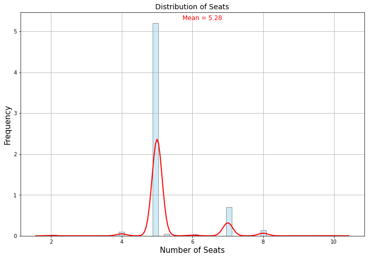

```python
plt.figure(figsize=(12,8))
sns.distplot(df2['Seats'],kde=True, hist=True, kde_kws={"color": "red", "lw": 2},
             hist_kws={"color": "skyblue", "edgecolor": "black"})
plt.xlabel("Number of Seats", fontsize=15)
plt.ylabel("Frequency", fontsize=15)
plt.title("Distribution of Seats", fontsize=14)
mean = np.mean(df2['Seats'])
plt.text(mean+1, mean, f'Mean = {mean:.2f}', color='red', fontsize=12, ha='center')
plt.grid(True,axis='both')
plt.show()
```

# Dropping the columns which are not required

```python
df3 = df2.drop(['S.No','Name','Company_name','Location','Fuel_Type',
                'Owner_Type','Mileage','Power'],axis=1)
```

```python
df3.head()
```

|  | Company_num | Location_num | Year | Kilometers_Driven | Transmission | Engine | Seats | Price |
| --- | --- | --- | --- | --- | --- | --- | --- | --- |
| 0 | 1.350000 | 7.753623 | 2003 | 80000 | 0 | 1489 | 5.0 | 1.35 |
| 1 | 25.537712 | 7.753623 | 2014 | 79271 | 1 | 1968 | 5.0 | 16.50 |
| 2 | 25.537712 | 7.753623 | 2014 | 70000 | 1 | 1968 | 5.0 | 18.00 |
| 3 | 25.537712 | 7.753623 | 2014 | 40000 | 1 | 1968 | 5.0 | 22.00 |
| 4 | 25.537712 | 7.753623 | 2016 | 11000 | 1 | 1968 | 5.0 | 28.00 |

```python
df3.dtypes
```

```
Company_num          float64
Location_num         float64
Year                   int64
Kilometers_Driven      int64
Transmission           int64
Engine                 int32
Seats                float64
Price                float64
dtype: object
```

# Dividing the data

```python
X = df3.drop(['Price'],axis=1)
y = df3[['Price']]
```

```python
X
```

|  | Company_num | Location_num | Year | Kilometers_Driven | Transmission | Engine | Seats |
| --- | --- | --- | --- | --- | --- | --- | --- |
| 0 | 1.350000 | 7.753623 | 2003 | 80000 | 0 | 1489 | 5.0 |
| 1 | 25.537712 | 7.753623 | 2014 | 79271 | 1 | 1968 | 5.0 |
| 2 | 25.537712 | 7.753623 | 2014 | 70000 | 1 | 1968 | 5.0 |
| 3 | 25.537712 | 7.753623 | 2014 | 40000 | 1 | 1968 | 5.0 |
| 4 | 25.537712 | 7.753623 | 2016 | 11000 | 1 | 1968 | 5.0 |
| ... | ... | ... | ... | ... | ... | ... | ... |
| 6014 | 5.307270 | 5.809225 | 2015 | 58000 | 0 | 1498 | 5.0 |
| 6015 | 5.307270 | 5.809225 | 2016 | 33000 | 0 | 1598 | 5.0 |
| 6016 | 5.307270 | 5.809225 | 2013 | 125000 | 0 | 1598 | 5.0 |
| 6017 | 5.307270 | 5.809225 | 2011 | 50000 | 0 | 1598 | 5.0 |
| 6018 | 5.307270 | 5.809225 | 2013 | 144000 | 0 | 1598 | 5.0 |

6019 rows × 7 columns

```python
y
```

|  | Price |
| --- | --- |
| 0 | 1.35 |
| 1 | 16.50 |
| 2 | 18.00 |
| 3 | 22.00 |
| 4 | 28.00 |
| ... | ... |
| 6014 | 5.85 |
| 6015 | 7.70 |
| 6016 | 6.25 |
| 6017 | 5.00 |
| 6018 | 7.00 |

6019 rows × 1 columns

```python
print(X.shape)
print(y.shape)
```

```
(6019, 7)
(6019, 1)
```

```python
X.isna().sum()
```

```
Company_num          0
Location_num         0
Year                 0
Kilometers_Driven    0
Transmission         0
Engine               0
Seats                0
dtype: int64
```

```python
y.isna().sum()
```

```
Price    0
dtype: int64
```

# Model Building

```python
import seaborn as sns
from sklearn.model_selection import train_test_split
from sklearn.linear_model import LinearRegression
```

```python
X_train,X_test,y_train,y_test = train_test_split(X,y,test_size=0.3,random_state=1)
```

```python
print(X_train.shape)
print(X_test.shape)
print(y_train.shape)
print(y_test.shape)
```

```
(4213, 7)
(1806, 7)
(4213, 1)
(1806, 1)
```

```python
reg = LinearRegression()
reg.fit(X_train,y_train)
```

```
LinearRegression()
```

```python
reg.coef_
```

```
array([[ 6.30361876e-01,  2.21943737e-01,  9.44448192e-01,
        -1.67132547e-05,  7.84728742e-01,  6.92307404e-03,
        -1.03122005e+00]])
```

```python
X_train.columns
```

```
Index(['Company_num', 'Location_num', 'Year', 'Kilometers_Driven',
       'Transmission', 'Engine', 'Seats'],
      dtype='object')
```

```python
for ind,col_name in enumerate(X_train.columns):
    print('The coeffcient of {} is {}'.format(col_name,reg.coef_[0][ind]))
```

```
The coeffcient of Company_num is 0.6303618761950565
The coeffcient of Location_num is 0.2219437368905355
The coeffcient of Year is 0.9444481920446072
The coeffcient of Kilometers_Driven is -1.6713254668065947e-05
The coeffcient of Transmission is 0.7847287418933205
The coeffcient of Engine is 0.006923074039491661
The coeffcient of Seats is -1.031220049009511
```

```python
reg.intercept_
```

```
array([-1905.1513256])
```

```python
reg.score(X_train,y_train) # Score of Train data
```

```
0.7316502507714125
```

```python
reg.score(X_test,y_test) # Score of Test data
```

```
0.6767601816073188
```

```python
train = pd.concat([X_train,y_train],axis=1)
train.head()
```

|  | Company_num | Location_num | Year | Kilometers_Driven | Transmission | Engine | Seats | Price |
| --- | --- | --- | --- | --- | --- | --- | --- | --- |
| 188 | 5.343433 | 7.753623 | 2003 | 44200 | 0 | 1997 | 5.0 | 1.50 |
| 4178 | 5.343433 | 13.328631 | 2014 | 54000 | 0 | 1197 | 5.0 | 5.50 |
| 3888 | 4.517267 | 8.457321 | 2015 | 42000 | 0 | 793 | 5.0 | 3.60 |
| 2242 | 4.517267 | 5.661215 | 2012 | 40000 | 0 | 998 | 5.0 | 2.35 |
| 2594 | 5.343433 | 9.776550 | 2008 | 80400 | 0 | 1086 | 5.0 | 2.30 |

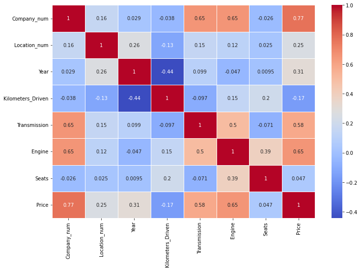

```python
plt.figure(figsize=(12,8))
cor_mat = train.corr()
sns.heatmap(cor_mat, annot=True, cmap='coolwarm', linewidths=0.5)
plt.show()
```

```python
import statsmodels.formula.api as smf
s1 = smf.ols(formula= 'Price ~ Company_num+Location_num+Year+Kilometers_Driven+Engine+Transmission+Seats',
             data = train).fit()
s1.params
```

```
Intercept           -1905.151326
Company_num             0.630362
Location_num            0.221944
Year                    0.944448
Kilometers_Driven      -0.000017
Engine                  0.006923
Transmission            0.784729
Seats                  -1.031220
dtype: float64
```

```python
print(s1.summary())
```

```
                            OLS Regression Results
==============================================================================
Dep. Variable:                  Price   R-squared:                       0.732
Model:                            OLS   Adj. R-squared:                  0.731
Method:                 Least Squares   F-statistic:                     1638.
Date:                Thu, 05 Oct 2023   Prob (F-statistic):               0.00
Time:                        19:07:28   Log-Likelihood:                -13448.
No. Observations:                4213   AIC:                         2.691e+04
Df Residuals:                    4205   BIC:                         2.696e+04
Df Model:                           7
Covariance Type:            nonrobust
=====================================================================================
                        coef    std err          t      P>|t|      [0.025      0.975]
-------------------------------------------------------------------------------------
Intercept         -1905.1513     64.843    -29.381      0.000   -2032.278   -1778.024
Company_num           0.6304      0.017     38.056      0.000       0.598       0.663
Location_num          0.2219      0.034      6.473      0.000       0.155       0.289
Year                  0.9444      0.032     29.293      0.000       0.881       1.008
Kilometers_Driven -1.671e-05    2.8e-06     -5.974      0.000   -2.22e-05   -1.12e-05
Engine                0.0069      0.000     28.028      0.000       0.006       0.007
Transmission          0.7847      0.275      2.852      0.004       0.245       1.324
Seats                -1.0312      0.138     -7.479      0.000      -1.302      -0.761
==============================================================================
Omnibus:                     3735.851   Durbin-Watson:                   2.039
Prob(Omnibus):                  0.000   Jarque-Bera (JB):           488665.721
Skew:                           3.678   Prob(JB):                         0.00
Kurtosis:                      55.246   Cond. No.                     4.90e+07
==============================================================================

Notes:
[1] Standard Errors assume that the covariance matrix of the errors is correctly specified.
[2] The condition number is large, 4.9e+07. This might indicate that there are
strong multicollinearity or other numerical problems.
```

```python
y_pred = reg.predict(X_test) # Predicted dependent values
```

```python
y_pred
```

```
array([[ 7.1294283 ],
       [ 6.53225221],
       [23.65275263],
       ...,
       [ 7.74208767],
       [21.91504787],
       [24.87195115]])
```

```python
from sklearn.metrics import mean_squared_error
```

```python
mean_squared_error(y_pred,y_test) # Calculating Mean Squared Error
```

```
37.370277520799725
```

# Linear relationship plot between Actual and Predicted Values

```
From the below plot, it is observed that there is a linear relationship
```

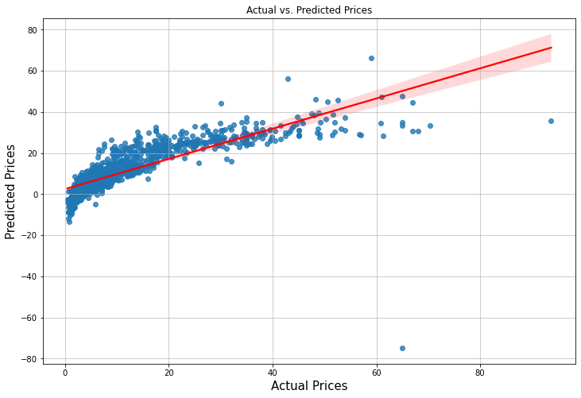

```python
# Using regplot which shows scatter and a linea regression line
print("From the below plot, it is observed that there is a linear relationship")
plt.figure(figsize=(12,8))
sns.regplot(x=y_test['Price'], y=y_pred, line_kws={"color": "red"})
plt.xlabel('Actual Prices',fontsize=15)
plt.ylabel('Predicted Prices',fontsize=15)
plt.title('Actual vs. Predicted Prices')

plt.grid(True, linestyle='-', alpha=0.8)

plt.show()
```

# |---------------------------------------------------|-----------------------------------------------------|

# For the model to be performed on test data and prediction, I have performed similar operations which I have done on the original dataset to make the test data accurate.

## Reading test file

```python
df_test = pd.read_excel('test-data (1).xlsx')
df_test
```

|  | S.no | Name | Location | Year | Kilometers_Driven | Fuel_Type | Transmission | Owner_Type | Mileage | Engine | Power | Seats | New_Price |
| --- | --- | --- | --- | --- | --- | --- | --- | --- | --- | --- | --- | --- | --- |
| 0 | 0 | Maruti Alto K10 LXI CNG | Delhi | 2014 | 40929 | CNG | Manual | First | 32.26 km/kg | 998 CC | 58.2 bhp | 4.0 | NaN |
| 1 | 1 | Maruti Alto 800 2016-2019 LXI | Coimbatore | 2013 | 54493 | Petrol | Manual | Second | 24.7 kmpl | 796 CC | 47.3 bhp | 5.0 | NaN |
| 2 | 2 | Toyota Innova Crysta Touring Sport 2.4 MT | Mumbai | 2017 | 34000 | Diesel | Manual | First | 13.68 kmpl | 2393 CC | 147.8 bhp | 7.0 | 25.27 Lakh |
| 3 | 3 | Toyota Etios Liva GD | Hyderabad | 2012 | 139000 | Diesel | Manual | First | 23.59 kmpl | 1364 CC | null bhp | 5.0 | NaN |
| 4 | 4 | Hyundai i20 Magna | Mumbai | 2014 | 29000 | Petrol | Manual | First | 18.5 kmpl | 1197 CC | 82.85 bhp | 5.0 | NaN |
| ... | ... | ... | ... | ... | ... | ... | ... | ... | ... | ... | ... | ... | ... |
| 1229 | 1229 | Volkswagen Vento Diesel Trendline | Hyderabad | 2011 | 89411 | Diesel | Manual | First | 20.54 kmpl | 1598 CC | 103.6 bhp | 5.0 | NaN |
| 1230 | 1230 | Volkswagen Polo GT TSI | Mumbai | 2015 | 59000 | Petrol | Automatic | First | 17.21 kmpl | 1197 CC | 103.6 bhp | 5.0 | NaN |
| 1231 | 1231 | Nissan Micra Diesel XV | Kolkata | 2012 | 28000 | Diesel | Manual | First | 23.08 kmpl | 1461 CC | 63.1 bhp | 5.0 | NaN |
| 1232 | 1232 | Volkswagen Polo GT TSI | Pune | 2013 | 52262 | Petrol | Automatic | Third | 17.2 kmpl | 1197 CC | 103.6 bhp | 5.0 | NaN |
| 1233 | 1233 | Mercedes-Benz E-Class 2009-2013 E 220 CDI Avan... | Kochi | 2014 | 72443 | Diesel | Automatic | First | 10.0 kmpl | 2148 CC | 170 bhp | 5.0 | NaN |

1234 rows × 13 columns

```python
df_test.info()
```

```
<class 'pandas.core.frame.DataFrame'>
RangeIndex: 1234 entries, 0 to 1233
Data columns (total 13 columns):
 #   Column             Non-Null Count  Dtype
---  ------             --------------  -----
 0   S.no               1234 non-null   int64
 1   Name               1234 non-null   object
 2   Location           1234 non-null   object
 3   Year               1234 non-null   int64
 4   Kilometers_Driven  1234 non-null   int64
 5   Fuel_Type          1234 non-null   object
 6   Transmission       1234 non-null   object
 7   Owner_Type         1234 non-null   object
 8   Mileage            1234 non-null   object
 9   Engine             1224 non-null   object
 10  Power              1224 non-null   object
 11  Seats              1223 non-null   float64
 12  New_Price          182 non-null    object
dtypes: float64(1), int64(3), object(9)
memory usage: 125.5+ KB
```

```python
new_col_values_test = df_test['Name'].str.split(' ').str[0]
```

```python
df_test.insert(loc = 2,
          column = 'Company_name',
          value = new_col_values_test)
```

```python
df_test
```

|  | S.no | Name | Company_name | Location | Year | Kilometers_Driven | Fuel_Type | Transmission | Owner_Type | Mileage | Engine | Power | Seats | New_Price |
| --- | --- | --- | --- | --- | --- | --- | --- | --- | --- | --- | --- | --- | --- | --- |
| 0 | 0 | Maruti Alto K10 LXI CNG | Maruti | Delhi | 2014 | 40929 | CNG | Manual | First | 32.26 km/kg | 998 CC | 58.2 bhp | 4.0 | NaN |
| 1 | 1 | Maruti Alto 800 2016-2019 LXI | Maruti | Coimbatore | 2013 | 54493 | Petrol | Manual | Second | 24.7 kmpl | 796 CC | 47.3 bhp | 5.0 | NaN |
| 2 | 2 | Toyota Innova Crysta Touring Sport 2.4 MT | Toyota | Mumbai | 2017 | 34000 | Diesel | Manual | First | 13.68 kmpl | 2393 CC | 147.8 bhp | 7.0 | 25.27 Lakh |
| 3 | 3 | Toyota Etios Liva GD | Toyota | Hyderabad | 2012 | 139000 | Diesel | Manual | First | 23.59 kmpl | 1364 CC | null bhp | 5.0 | NaN |
| 4 | 4 | Hyundai i20 Magna | Hyundai | Mumbai | 2014 | 29000 | Petrol | Manual | First | 18.5 kmpl | 1197 CC | 82.85 bhp | 5.0 | NaN |
| ... | ... | ... | ... | ... | ... | ... | ... | ... | ... | ... | ... | ... | ... | ... |
| 1229 | 1229 | Volkswagen Vento Diesel Trendline | Volkswagen | Hyderabad | 2011 | 89411 | Diesel | Manual | First | 20.54 kmpl | 1598 CC | 103.6 bhp | 5.0 | NaN |
| 1230 | 1230 | Volkswagen Polo GT TSI | Volkswagen | Mumbai | 2015 | 59000 | Petrol | Automatic | First | 17.21 kmpl | 1197 CC | 103.6 bhp | 5.0 | NaN |
| 1231 | 1231 | Nissan Micra Diesel XV | Nissan | Kolkata | 2012 | 28000 | Diesel | Manual | First | 23.08 kmpl | 1461 CC | 63.1 bhp | 5.0 | NaN |
| 1232 | 1232 | Volkswagen Polo GT TSI | Volkswagen | Pune | 2013 | 52262 | Petrol | Automatic | Third | 17.2 kmpl | 1197 CC | 103.6 bhp | 5.0 | NaN |
| 1233 | 1233 | Mercedes-Benz E-Class 2009-2013 E 220 CDI Avan... | Mercedes-Benz | Kochi | 2014 | 72443 | Diesel | Automatic | First | 10.0 kmpl | 2148 CC | 170 bhp | 5.0 | NaN |

1234 rows × 14 columns

```python
piv_tab_comp_Price
```

|  | Company_name | Price |
| --- | --- | --- |
| 0 | Ambassador | 1.350000 |
| 1 | Audi | 25.537712 |
| 2 | BMW | 25.243146 |
| 3 | Bentley | 59.000000 |
| 4 | Chevrolet | 3.044463 |
| 5 | Datsun | 3.049231 |
| 6 | Fiat | 3.269286 |
| 7 | Force | 9.333333 |
| 8 | Ford | 6.889400 |
| 9 | Honda | 5.411743 |
| 10 | Hyundai | 5.343433 |
| 11 | ISUZU | 12.045000 |
| 12 | Isuzu | 20.000000 |
| 13 | Jaguar | 37.632250 |
| 14 | Jeep | 18.718667 |
| 15 | Lamborghini | 120.000000 |
| 16 | Land | 39.259500 |
| 17 | Mahindra | 8.045919 |
| 18 | Maruti | 4.517267 |
| 19 | Mercedes-Benz | 26.809874 |
| 20 | Mini | 26.896923 |
| 21 | Mitsubishi | 11.058889 |
| 22 | Nissan | 4.738352 |
| 23 | Porsche | 48.348333 |
| 24 | Renault | 5.799034 |
| 25 | Skoda | 7.559075 |
| 26 | Smart | 3.000000 |
| 27 | Tata | 3.562849 |
| 28 | Toyota | 11.580024 |
| 29 | Volkswagen | 5.307270 |
| 30 | Volvo | 18.802857 |

```python
df_test = pd.merge(df_test,piv_tab_comp_Price,on='Company_name',how='inner')
```

```python
piv_tab_loca_price
```

|  | Location | Price |
| --- | --- | --- |
| 0 | Ahmedabad | 8.457321 |
| 1 | Bangalore | 13.328631 |
| 2 | Chennai | 7.753623 |
| 3 | Coimbatore | 15.078223 |
| 4 | Delhi | 9.707726 |
| 5 | Hyderabad | 9.776550 |
| 6 | Jaipur | 5.809225 |
| 7 | Kochi | 11.179186 |
| 8 | Kolkata | 5.661215 |
| 9 | Mumbai | 9.429329 |
| 10 | Pune | 6.726254 |

```python
df_test = pd.merge(df_test,piv_tab_loca_price,on='Location',how='inner')
```

```python
df_test.head()
```

|  | S.no | Name | Company_name | Location | Year | Kilometers_Driven | Fuel_Type | Transmission | Owner_Type | Mileage | Engine | Power | Seats | New_Price | Price_x | Price_y |
| --- | --- | --- | --- | --- | --- | --- | --- | --- | --- | --- | --- | --- | --- | --- | --- | --- |
| 0 | 0 | Maruti Alto K10 LXI CNG | Maruti | Delhi | 2014 | 40929 | CNG | Manual | First | 32.26 km/kg | 998 CC | 58.2 bhp | 4.0 | NaN | 4.517267 | 9.707726 |
| 1 | 68 | Maruti Wagon R LXI | Maruti | Delhi | 2009 | 55000 | Petrol | Manual | Second | 18.9 kmpl | 998 CC | 67.1 bhp | 5.0 | NaN | 4.517267 | 9.707726 |
| 2 | 118 | Maruti Swift Dzire Vdi BSIV | Maruti | Delhi | 2015 | 51000 | Diesel | Manual | First | 19.3 kmpl | 1248 CC | 73.9 bhp | 5.0 | NaN | 4.517267 | 9.707726 |
| 3 | 147 | Maruti Wagon R LXI | Maruti | Delhi | 2012 | 64692 | Petrol | Manual | First | 22.5 kmpl | 998 CC | 67.04 bhp | 5.0 | 4.59 Lakh | 4.517267 | 9.707726 |
| 4 | 154 | Maruti Baleno Alpha 1.2 | Maruti | Delhi | 2016 | 20185 | Petrol | Manual | First | 21.4 kmpl | 1197 CC | 83.1 bhp | 5.0 | NaN | 4.517267 | 9.707726 |

```python
df_test = df_test.rename({'Price_x':'Company_num','Price_y':'Location_num'},axis=1)
```

```python
df_test
```

|  | S.no | Name | Company_name | Location | Year | Kilometers_Driven | Fuel_Type | Transmission | Owner_Type | Mileage | Engine | Power | Seats | New_Price | Company_num | Location_num |
| --- | --- | --- | --- | --- | --- | --- | --- | --- | --- | --- | --- | --- | --- | --- | --- | --- |
| 0 | 0 | Maruti Alto K10 LXI CNG | Maruti | Delhi | 2014 | 40929 | CNG | Manual | First | 32.26 km/kg | 998 CC | 58.2 bhp | 4.0 | NaN | 4.517267 | 9.707726 |
| 1 | 68 | Maruti Wagon R LXI | Maruti | Delhi | 2009 | 55000 | Petrol | Manual | Second | 18.9 kmpl | 998 CC | 67.1 bhp | 5.0 | NaN | 4.517267 | 9.707726 |
| 2 | 118 | Maruti Swift Dzire Vdi BSIV | Maruti | Delhi | 2015 | 51000 | Diesel | Manual | First | 19.3 kmpl | 1248 CC | 73.9 bhp | 5.0 | NaN | 4.517267 | 9.707726 |
| 3 | 147 | Maruti Wagon R LXI | Maruti | Delhi | 2012 | 64692 | Petrol | Manual | First | 22.5 kmpl | 998 CC | 67.04 bhp | 5.0 | 4.59 Lakh | 4.517267 | 9.707726 |
| 4 | 154 | Maruti Baleno Alpha 1.2 | Maruti | Delhi | 2016 | 20185 | Petrol | Manual | First | 21.4 kmpl | 1197 CC | 83.1 bhp | 5.0 | NaN | 4.517267 | 9.707726 |
| ... | ... | ... | ... | ... | ... | ... | ... | ... | ... | ... | ... | ... | ... | ... | ... | ... |
| 1227 | 638 | Renault Captur 1.5 Diesel RXL | Renault | Bangalore | 2018 | 22000 | Diesel | Manual | First | 20.37 kmpl | 1461 CC | 108.45 bhp | 5.0 | NaN | 5.799034 | 13.328631 |
| 1228 | 880 | Renault Duster 110PS Diesel RxZ AMT | Renault | Bangalore | 2016 | 56839 | Diesel | Automatic | First | 19.6 kmpl | 1461 CC | 108.45 bhp | 5.0 | 15.05 Lakh | 5.799034 | 13.328631 |
| 1229 | 335 | Bentley Flying Spur W12 | Bentley | Bangalore | 2008 | 31200 | Petrol | Automatic | Second | 10.2 kmpl | 5998 CC | 616 bhp | 5.0 | 3.75 Cr | 59.000000 | 13.328631 |
| 1230 | 365 | Volvo XC90 2007-2015 D5 AWD | Volvo | Bangalore | 2016 | 70000 | Diesel | Manual | First | 11.1 kmpl | 2400 CC | 200 bhp | 7.0 | NaN | 18.802857 | 13.328631 |
| 1231 | 721 | Porsche Cayenne Diesel | Porsche | Bangalore | 2014 | 43000 | Diesel | Automatic | Second | 15.15 kmpl | 2967 CC | 240 bhp | 5.0 | NaN | 48.348333 | 13.328631 |

1232 rows × 16 columns

```python
df_test.isnull().sum()
```

```
S.no                    0
Name                    0
Company_name            0
Location                0
Year                    0
Kilometers_Driven       0
Fuel_Type               0
Transmission            0
Owner_Type              0
Mileage                 0
Engine                 10
Power                  10
Seats                  11
New_Price            1050
Company_num             0
Location_num            0
dtype: int64
```

```python
df_test[df_test['Company_num'].isnull()]
```

|  | S.no | Name | Company_name | Location | Year | Kilometers_Driven | Fuel_Type | Transmission | Owner_Type | Mileage | Engine | Power | Seats | New_Price | Company_num | Location_num |
| --- | --- | --- | --- | --- | --- | --- | --- | --- | --- | --- | --- | --- | --- | --- | --- | --- |

```python
df_test.Engine.isnull().sum()
```

```
10
```

```python
df_test.Engine.unique()
```

```
array(['998 CC', '1248 CC', '1197 CC', '1196 CC', '1373 CC', '1462 CC',
       '1298 CC', '2494 CC', '1496 CC', '2982 CC', '1798 CC', '2755 CC',
       '1591 CC', '1582 CC', '814 CC', '1086 CC', '1396 CC', '2179 CC',
       '2498 CC', '1198 CC', '2523 CC', '1497 CC', '1498 CC', '2354 CC',
       '1968 CC', '1461 CC', '1995 CC', '4395 CC', '2993 CC', '2953 CC',
       '1499 CC', '1199 CC', '2477 CC', '2143 CC', '2987 CC', '1950 CC',
       '1796 CC', '624 CC', '799 CC', '2400 CC', '1956 CC', '796 CC',
       '1364 CC', '2393 CC', '1493 CC', '1797 CC', '1186 CC', '2489 CC',
       '2967 CC', '2349 CC', '999 CC', '1388 CC', '1598 CC', '2996 CC',
       '936 CC', '1998 CC', '1999 CC', '1984 CC', '1586 CC', nan,
       '2979 CC', '1896 CC', '1991 CC', '2148 CC', '1368 CC', '1061 CC',
       '1495 CC', '1120 CC', '1399 CC', '1172 CC', '995 CC', '2499 CC',
       '1590 CC', '2446 CC', '2359 CC', '1799 CC', '1299 CC', '1405 CC',
       '1047 CC', '1599 CC', '2000 CC', '3696 CC', '1193 CC', '1997 CC',
       '2999 CC', '1794 CC', '2362 CC', '2198 CC', '2835 CC', '1948 CC',
       '1150 CC', '2487 CC', '1341 CC', '2696 CC', '2496 CC', '2495 CC',
       '1596 CC', '1595 CC', '3498 CC', '2497 CC', '1795 CC', '793 CC',
       '2147 CC', '5998 CC'], dtype=object)
```

```python
df_test['Engine'] = df_test['Engine'].str.split(' ').str[0]
```

```python
df_test['Engine'].unique()
```

```
array(['998', '1248', '1197', '1196', '1373', '1462', '1298', '2494',
       '1496', '2982', '1798', '2755', '1591', '1582', '814', '1086',
       '1396', '2179', '2498', '1198', '2523', '1497', '1498', '2354',
       '1968', '1461', '1995', '4395', '2993', '2953', '1499', '1199',
       '2477', '2143', '2987', '1950', '1796', '624', '799', '2400',
       '1956', '796', '1364', '2393', '1493', '1797', '1186', '2489',
       '2967', '2349', '999', '1388', '1598', '2996', '936', '1998',
       '1999', '1984', '1586', nan, '2979', '1896', '1991', '2148',
       '1368', '1061', '1495', '1120', '1399', '1172', '995', '2499',
       '1590', '2446', '2359', '1799', '1299', '1405', '1047', '1599',
       '2000', '3696', '1193', '1997', '2999', '1794', '2362', '2198',
       '2835', '1948', '1150', '2487', '1341', '2696', '2496', '2495',
       '1596', '1595', '3498', '2497', '1795', '793', '2147', '5998'],
      dtype=object)
```

```python
int(mean_of_engine)
```

```
1612
```

```python
df_test.Engine = df_test.Engine.replace(np.nan,int(mean_of_engine))
```

```python
df_test['Engine'].unique()
```

```
array(['998', '1248', '1197', '1196', '1373', '1462', '1298', '2494',
       '1496', '2982', '1798', '2755', '1591', '1582', '814', '1086',
       '1396', '2179', '2498', '1198', '2523', '1497', '1498', '2354',
       '1968', '1461', '1995', '4395', '2993', '2953', '1499', '1199',
       '2477', '2143', '2987', '1950', '1796', '624', '799', '2400',
       '1956', '796', '1364', '2393', '1493', '1797', '1186', '2489',
       '2967', '2349', '999', '1388', '1598', '2996', '936', '1998',
       '1999', '1984', '1586', 1612, '2979', '1896', '1991', '2148',
       '1368', '1061', '1495', '1120', '1399', '1172', '995', '2499',
       '1590', '2446', '2359', '1799', '1299', '1405', '1047', '1599',
       '2000', '3696', '1193', '1997', '2999', '1794', '2362', '2198',
       '2835', '1948', '1150', '2487', '1341', '2696', '2496', '2495',
       '1596', '1595', '3498', '2497', '1795', '793', '2147', '5998'],
      dtype=object)
```

```python
df_test['Engine'] = df_test['Engine'] .astype(int)
```

```python
df_test.Engine.unique()
```

```
array([ 998, 1248, 1197, 1196, 1373, 1462, 1298, 2494, 1496, 2982, 1798,
       2755, 1591, 1582,  814, 1086, 1396, 2179, 2498, 1198, 2523, 1497,
       1498, 2354, 1968, 1461, 1995, 4395, 2993, 2953, 1499, 1199, 2477,
       2143, 2987, 1950, 1796,  624,  799, 2400, 1956,  796, 1364, 2393,
       1493, 1797, 1186, 2489, 2967, 2349,  999, 1388, 1598, 2996,  936,
       1998, 1999, 1984, 1586, 1612, 2979, 1896, 1991, 2148, 1368, 1061,
       1495, 1120, 1399, 1172,  995, 2499, 1590, 2446, 2359, 1799, 1299,
       1405, 1047, 1599, 2000, 3696, 1193, 1997, 2999, 1794, 2362, 2198,
       2835, 1948, 1150, 2487, 1341, 2696, 2496, 2495, 1596, 1595, 3498,
       2497, 1795,  793, 2147, 5998])
```

```python
df_test['Engine'].dtype
```

```
dtype('int32')
```

```python
df_test.head()
```

|  | S.no | Name | Company_name | Location | Year | Kilometers_Driven | Fuel_Type | Transmission | Owner_Type | Mileage | Engine | Power | Seats | New_Price | Company_num | Location_num |
| --- | --- | --- | --- | --- | --- | --- | --- | --- | --- | --- | --- | --- | --- | --- | --- | --- |
| 0 | 0 | Maruti Alto K10 LXI CNG | Maruti | Delhi | 2014 | 40929 | CNG | Manual | First | 32.26 km/kg | 998 | 58.2 bhp | 4.0 | NaN | 4.517267 | 9.707726 |
| 1 | 68 | Maruti Wagon R LXI | Maruti | Delhi | 2009 | 55000 | Petrol | Manual | Second | 18.9 kmpl | 998 | 67.1 bhp | 5.0 | NaN | 4.517267 | 9.707726 |
| 2 | 118 | Maruti Swift Dzire Vdi BSIV | Maruti | Delhi | 2015 | 51000 | Diesel | Manual | First | 19.3 kmpl | 1248 | 73.9 bhp | 5.0 | NaN | 4.517267 | 9.707726 |
| 3 | 147 | Maruti Wagon R LXI | Maruti | Delhi | 2012 | 64692 | Petrol | Manual | First | 22.5 kmpl | 998 | 67.04 bhp | 5.0 | 4.59 Lakh | 4.517267 | 9.707726 |
| 4 | 154 | Maruti Baleno Alpha 1.2 | Maruti | Delhi | 2016 | 20185 | Petrol | Manual | First | 21.4 kmpl | 1197 | 83.1 bhp | 5.0 | NaN | 4.517267 | 9.707726 |

```python
df_test.head(5)
```

|  | S.no | Name | Company_name | Location | Year | Kilometers_Driven | Fuel_Type | Transmission | Owner_Type | Mileage | Engine | Power | Seats | New_Price | Company_num | Location_num |
| --- | --- | --- | --- | --- | --- | --- | --- | --- | --- | --- | --- | --- | --- | --- | --- | --- |
| 0 | 0 | Maruti Alto K10 LXI CNG | Maruti | Delhi | 2014 | 40929 | CNG | Manual | First | 32.26 km/kg | 998 | 58.2 bhp | 4.0 | NaN | 4.517267 | 9.707726 |
| 1 | 68 | Maruti Wagon R LXI | Maruti | Delhi | 2009 | 55000 | Petrol | Manual | Second | 18.9 kmpl | 998 | 67.1 bhp | 5.0 | NaN | 4.517267 | 9.707726 |
| 2 | 118 | Maruti Swift Dzire Vdi BSIV | Maruti | Delhi | 2015 | 51000 | Diesel | Manual | First | 19.3 kmpl | 1248 | 73.9 bhp | 5.0 | NaN | 4.517267 | 9.707726 |
| 3 | 147 | Maruti Wagon R LXI | Maruti | Delhi | 2012 | 64692 | Petrol | Manual | First | 22.5 kmpl | 998 | 67.04 bhp | 5.0 | 4.59 Lakh | 4.517267 | 9.707726 |
| 4 | 154 | Maruti Baleno Alpha 1.2 | Maruti | Delhi | 2016 | 20185 | Petrol | Manual | First | 21.4 kmpl | 1197 | 83.1 bhp | 5.0 | NaN | 4.517267 | 9.707726 |

```python
df_test['Transmission'] =  df_test['Transmission'].apply(lambda x : 1 if x=='Automatic' else 0)
```

```python
df_test['Transmission'].unique()
```

```
array([0, 1], dtype=int64)
```

```python
df_test.head(5)
```

|  | S.no | Name | Company_name | Location | Year | Kilometers_Driven | Fuel_Type | Transmission | Owner_Type | Mileage | Engine | Power | Seats | New_Price | Company_num | Location_num |
| --- | --- | --- | --- | --- | --- | --- | --- | --- | --- | --- | --- | --- | --- | --- | --- | --- |
| 0 | 0 | Maruti Alto K10 LXI CNG | Maruti | Delhi | 2014 | 40929 | CNG | 0 | First | 32.26 km/kg | 998 | 58.2 bhp | 4.0 | NaN | 4.517267 | 9.707726 |
| 1 | 68 | Maruti Wagon R LXI | Maruti | Delhi | 2009 | 55000 | Petrol | 0 | Second | 18.9 kmpl | 998 | 67.1 bhp | 5.0 | NaN | 4.517267 | 9.707726 |
| 2 | 118 | Maruti Swift Dzire Vdi BSIV | Maruti | Delhi | 2015 | 51000 | Diesel | 0 | First | 19.3 kmpl | 1248 | 73.9 bhp | 5.0 | NaN | 4.517267 | 9.707726 |
| 3 | 147 | Maruti Wagon R LXI | Maruti | Delhi | 2012 | 64692 | Petrol | 0 | First | 22.5 kmpl | 998 | 67.04 bhp | 5.0 | 4.59 Lakh | 4.517267 | 9.707726 |
| 4 | 154 | Maruti Baleno Alpha 1.2 | Maruti | Delhi | 2016 | 20185 | Petrol | 0 | First | 21.4 kmpl | 1197 | 83.1 bhp | 5.0 | NaN | 4.517267 | 9.707726 |

```python
df_test['Seats'].dtype
```

```
dtype('float64')
```

```python
df_test['Seats'] = df_test['Seats'].replace(np.nan,df_test['Seats'].mean)
```

```python
df_test['Seats'].isnull().sum()
```

```
0
```

```python
df_test.columns
```

```
Index(['S.no', 'Name', 'Company_name', 'Location', 'Year', 'Kilometers_Driven',
       'Fuel_Type', 'Transmission', 'Owner_Type', 'Mileage', 'Engine', 'Power',
       'Seats', 'New_Price', 'Company_num', 'Location_num'],
      dtype='object')
```

```python
df_test1= df_test.drop(['S.no', 'Name', 'Company_name', 'Location',
       'Fuel_Type', 'Owner_Type', 'Mileage','Power','New_Price'],axis=1)
```

```python
df_test1.dtypes
```

```
Year                   int64
Kilometers_Driven      int64
Transmission           int64
Engine                 int32
Seats                 object
Company_num          float64
Location_num         float64
dtype: object
```

```python
df_test1['Seats'] = pd.to_numeric(df_test1['Seats'],errors='coerce')
```

```python
df_test1.head(3)
```

|  | Year | Kilometers_Driven | Transmission | Engine | Seats | Company_num | Location_num |
| --- | --- | --- | --- | --- | --- | --- | --- |
| 0 | 2014 | 40929 | 0 | 998 | 4.0 | 4.517267 | 9.707726 |
| 1 | 2009 | 55000 | 0 | 998 | 5.0 | 4.517267 | 9.707726 |
| 2 | 2015 | 51000 | 0 | 1248 | 5.0 | 4.517267 | 9.707726 |

```python
df_test1.dtypes
```

```
Year                   int64
Kilometers_Driven      int64
Transmission           int64
Engine                 int32
Seats                float64
Company_num          float64
Location_num         float64
dtype: object
```

```python
df_test1['Seats'].isnull().sum()
```

```
11
```